# Exploring the Palmer Penguins: Sex, Species, and Island Differences

Tamer

```r
# Load all libraries needed for this project
library(readxl)          # reads the .xlsx data file
library(tidyverse)       # includes dplyr (data wrangling) and ggplot2 (plotting)
library(knitr)           # for nicely formatted tables with kable()
```

## Introduction

The Palmer Penguins dataset was collected and made available by the Palmer Station Long Term Ecological Research (LTER) Program, part of a research network. The data describe three penguin species – Adelie, Chinstrap, and Gentoo – observed on three islands (Biscoe, Dream, and Torgersen) in the Palmer Archipelago, Antarctica. For each penguin, researchers recorded physical measurements such as bill length, bill depth, flipper length, and body mass, along with sex, species, island, and the year of observation.

This dataset was featured in a 2014 study, which examined how body size and shape relate to sex and ecological factors like foraging behavior and isotopic (diet-related) signatures across the threepenguin species.

In this exploration, I want to use these measurements to answer a few guiding questions:

- How many penguins and how many variables does this dataset contain?
- Are males and females represented equally in the data?
- Are all three species and all three islands represented equally?
- Which physical measurements best distinguish males from females?
- Which physical measurements best distinguish the three species from one another?
- Which islands are home to which species?

## Load the Data

```r
# Load libraries and dataset
library(palmerpenguins)
library(tidyverse)

# Assign built-in dataset directly
data("penguins")

# Quick check that the data loaded properly
head(penguins)
```

```
## # A tibble: 6 × 8
##   species island    bill_length_mm bill_depth_mm flipper_length_mm body_mass_g
##   <fct>   <fct>              <dbl>         <dbl>             <int>       <int>
## 1 Adelie  Torgersen           39.1          18.7               181        3750
## 2 Adelie  Torgersen           39.5          17.4               186        3800
## 3 Adelie  Torgersen           40.3          18                 195        3250
## 4 Adelie  Torgersen           NA            NA                  NA          NA
## 5 Adelie  Torgersen           36.7          19.3               193        3450
## 6 Adelie  Torgersen           39.3          20.6               190        3650
## # ℹ 2 more variables: sex <fct>, year <int>
```

```r
## Exploratory Analysis
```

```r
# Look at the overall structure of the dataset: number of rows/columns,
# variable names, and data types
str(penguins)
```

```
## tibble [344 × 8] (S3: tbl_df/tbl/data.frame)
##  $ species          : Factor w/ 3 levels "Adelie","Chinstrap",..: 1 1 1 1 1 1 1 1 1 1 ...
##  $ island           : Factor w/ 3 levels "Biscoe","Dream",..: 3 3 3 3 3 3 3 3 3 3 ...
##  $ bill_length_mm   : num [1:344] 39.1 39.5 40.3 NA 36.7 39.3 38.9 39.2 34.1 42 ...
##  $ bill_depth_mm    : num [1:344] 18.7 17.4 18 NA 19.3 20.6 17.8 19.6 18.1 20.2 ...
##  $ flipper_length_mm: int [1:344] 181 186 195 NA 193 190 181 195 193 190 ...
##  $ body_mass_g      : int [1:344] 3750 3800 3250 NA 3450 3650 3625 4675 3475 4250 ...
##  $ sex              : Factor w/ 2 levels "female","male": 2 1 1 NA 1 2 1 2 NA NA ...
##  $ year             : int [1:344] 2007 2007 2007 2007 2007 2007 2007 2007 2007 2007 ...
```

### How many data columns are in `penguins`?

```r
# ncol() counts the number of columns (variables) in the dataframe
ncol(penguins)
```

```
## [1] 8
```

There are 8 columns in the `penguins` dataframe.

### How many penguins do we have data for?

```r
# nrow() counts the number of rows (individual penguins) in the dataframe
nrow(penguins)
```

```
## [1] 344
```

There are 344 penguins recorded in the dataset.

### Do we have equal representation of males and females?

```r
# table() with useNA shows counts for male, female, AND any missing (NA)
# sex values -- important because 'sex' has some NAs that a naive grep()
# or subset on "male" would either miss or (worse) accidentally match,
# since the string "female" contains the substring "male" inside it!
table(penguins$sex, useNA = "ifany")
```

```
##
## female   male   <NA>
##    165    168     11
```

```r
# Build pmale using an EXACT equality check (not grep/string matching),
# so that "female" rows are never mistakenly captured as "male"
pmale <- penguins %>% filter(sex == "male")

# Build pfemale the same safe way
pfemale <- penguins %>% filter(sex == "female")

# Compare counts
nrow(pmale)
```

```
## [1] 168
```

```r
nrow(pfemale)
```

```
## [1] 165
```

The counts of male and female penguins are very close (168 males vs. 165 females), so representation is nearly, but not perfectly, balanced. There are also a handful of penguins with missing (`NA`) sex data that fall into neither group. Note the care taken above: since the string `"female"` literally contains `"male"` as a substring, a careless `grep("male", ...)` search would incorrectly pull female penguins into the male group. Using an exact `==` comparison avoids that trap entirely.

### Do we have equal representation of each species?

```r
# Count how many penguins belong to each species
table(penguins$species)
```

```
##
##    Adelie Chinstrap    Gentoo
##       152        68       124
```

```r
# Split into three separate dataframes, one per species
pAdel <- penguins %>% filter(species == "Adelie")
pChin <- penguins %>% filter(species == "Chinstrap")
pGen  <- penguins %>% filter(species == "Gentoo")

nrow(pAdel)
```

```
## [1] 152
```

```r
nrow(pChin)
```

```
## [1] 68
```

```r
nrow(pGen)
```

```
## [1] 124
```

Species representation is not balanced: Adelie penguins are the most numerous (152), followed by Gentoo (124), with Chinstrap the least represented (68).

### Do we have equal representation of each island?

```r
# Count how many penguins were observed on each island
table(penguins$island)
```

```
##
##    Biscoe     Dream Torgersen
##       168       124        52
```

```r
# Split into three separate dataframes, one per island
iBis   <- penguins %>% filter(island == "Biscoe")
iDream <- penguins %>% filter(island == "Dream")
iTorg  <- penguins %>% filter(island == "Torgersen")

nrow(iBis)
```

```
## [1] 168
```

```r
nrow(iDream)
```

```
## [1] 124
```

```r
nrow(iTorg)
```

```
## [1] 52
```

Island representation is also unbalanced: Biscoe has the most observations (168), Dream is next (124), and Torgersen has the fewest (52).

## Data Visualization

### What measured values most clearly distinguish male and female penguins?

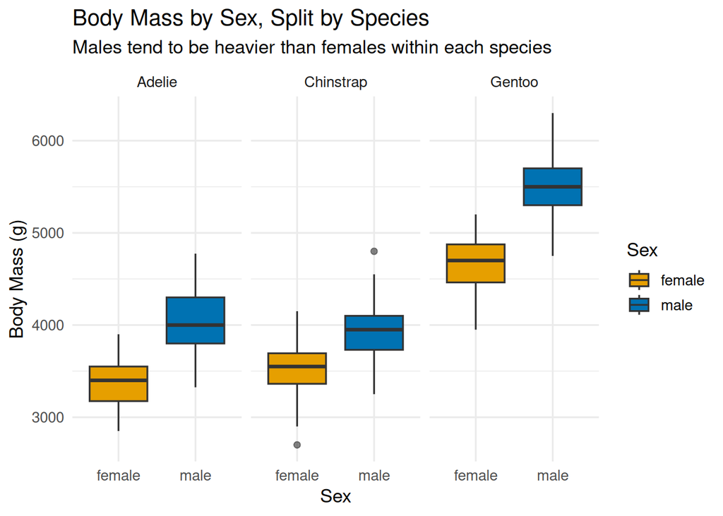

```r
# A boxplot comparing body mass between sexes, faceted by species since
# body size varies a lot by species -- this helps isolate the sex effect
penguins %>%
  filter(!is.na(sex)) %>%
  ggplot(aes(x = sex, y = body_mass_g, fill = sex)) +
  geom_boxplot(outlier.alpha = 0.6) +                 # style function 1: transparency on outliers
  facet_wrap(~species) +
  scale_fill_manual(values = c("female" = "#E69F00", "male" = "#0072B2")) + # style function 2: custom color palette
  labs(
    title = "Body Mass by Sex, Split by Species",
    subtitle = "Males tend to be heavier than females within each species",
    x = "Sex",
    y = "Body Mass (g)",
    fill = "Sex"
  ) +
  theme_minimal(base_size = 13)
```

Body mass shows a clear separation between males and females within every species, with males consistently heavier – making it one of the better single measurements for distinguishing sex.

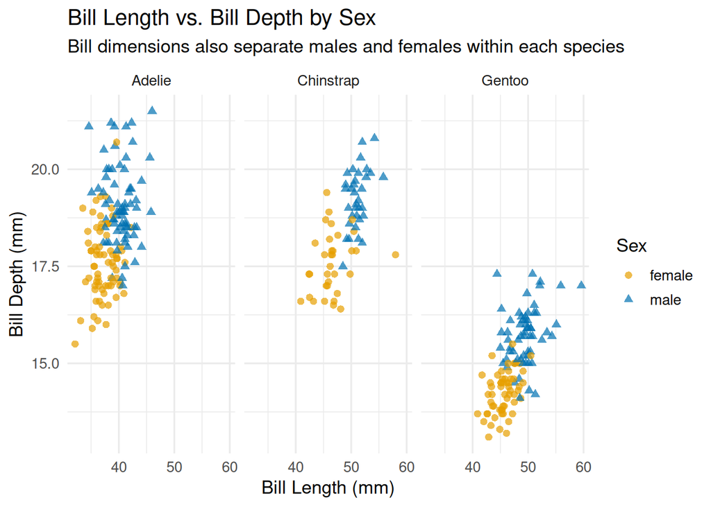

```r
# A scatterplot of bill length vs. bill depth, colored by sex, to see if
# bill shape also separates the sexes
penguins %>%
  filter(!is.na(sex)) %>%
  ggplot(aes(x = bill_length_mm, y = bill_depth_mm, color = sex, shape = sex)) +
  geom_point(size = 2, alpha = 0.7) +                  # style function 1: point transparency
  facet_wrap(~species) +
  scale_color_manual(values = c("female" = "#E69F00", "male" = "#0072B2")) + # style function 2: custom colors
  labs(
    title = "Bill Length vs. Bill Depth by Sex",
    subtitle = "Bill dimensions also separate males and females within each species",
    x = "Bill Length (mm)",
    y = "Bill Depth (mm)",
    color = "Sex",
    shape = "Sex"
  ) +
  theme_minimal(base_size = 13)
```

### What measured values most clearly distinguish each species?

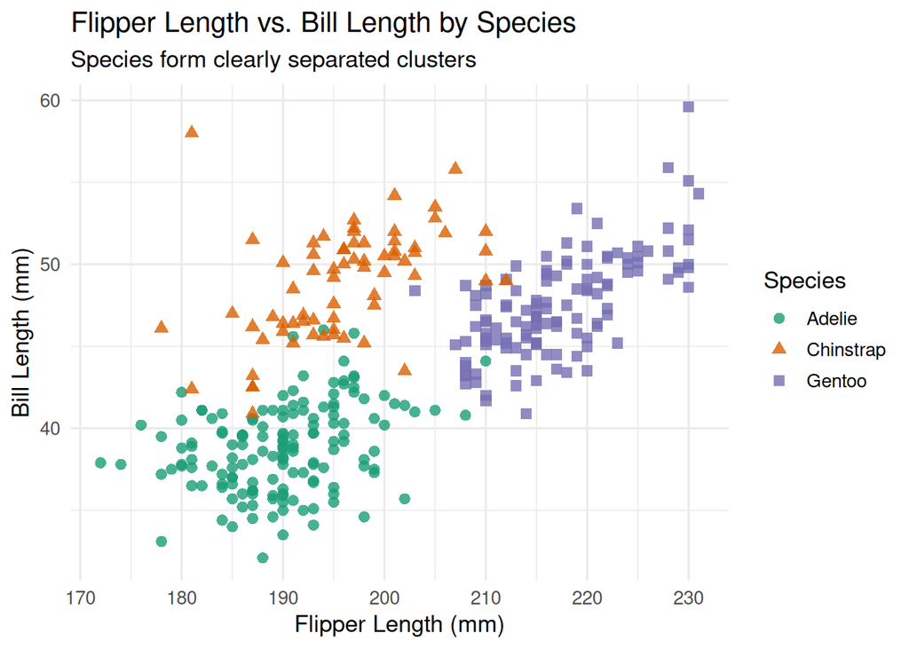

```r
# Flipper length vs. bill length tends to separate species very cleanly
penguins %>%
  filter(!is.na(species)) %>%
  ggplot(aes(x = flipper_length_mm, y = bill_length_mm, color = species, shape = species)) +
  geom_point(size = 2.5, alpha = 0.8) +
  scale_color_brewer(palette = "Dark2") +               # style function: colorblind-friendly palette
  labs(
    title = "Flipper Length vs. Bill Length by Species",
    subtitle = "Species form clearly separated clusters",
    x = "Flipper Length (mm)",
    y = "Bill Length (mm)",
    color = "Species",
    shape = "Species"
  ) +
  theme_minimal(base_size = 13)
```

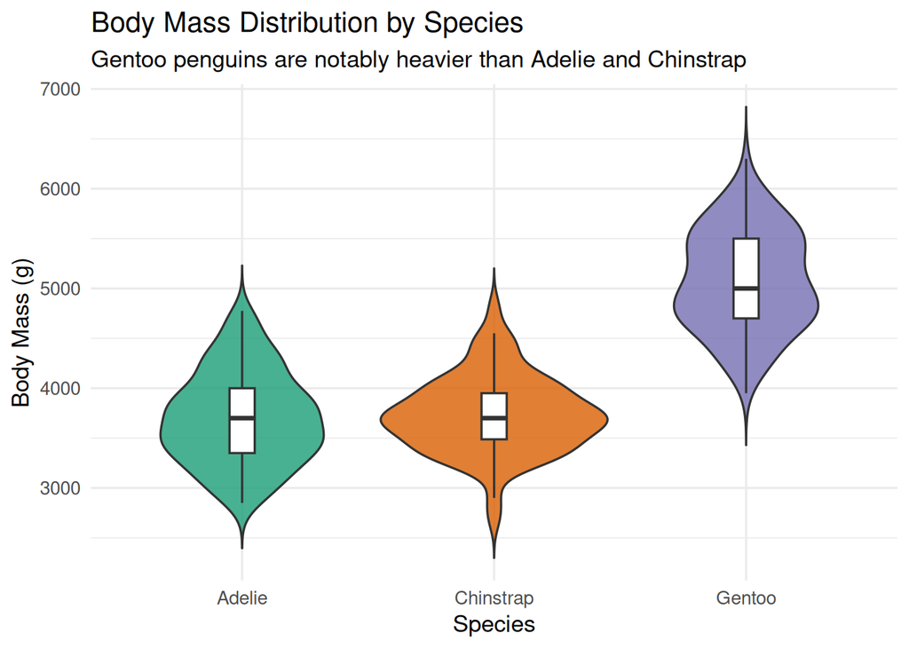

```r
# A violin plot of body mass by species shows the full distribution shape,
# not just a summary, which is useful when distributions might be skewed
penguins %>%
  filter(!is.na(species)) %>%
  ggplot(aes(x = species, y = body_mass_g, fill = species)) +
  geom_violin(trim = FALSE, alpha = 0.8) +               # style function 1: don't trim tails, add transparency
  geom_boxplot(width = 0.1, fill = "white", outlier.shape = NA) + # overlay a slim boxplot for reference
  scale_fill_brewer(palette = "Dark2") +                 # style function 2: consistent colorblind-friendly palette
  labs(
    title = "Body Mass Distribution by Species",
    subtitle = "Gentoo penguins are notably heavier than Adelie and Chinstrap",
    x = "Species",
    y = "Body Mass (g)"
  ) +
  theme_minimal(base_size = 13) +
  theme(legend.position = "none")
```

Flipper length and bill length together separate the three species into distinct clusters, and body mass clearly sets Gentoo penguins apart from the other two species, which overlap more with each other.

### Which penguin species inhabit each island?

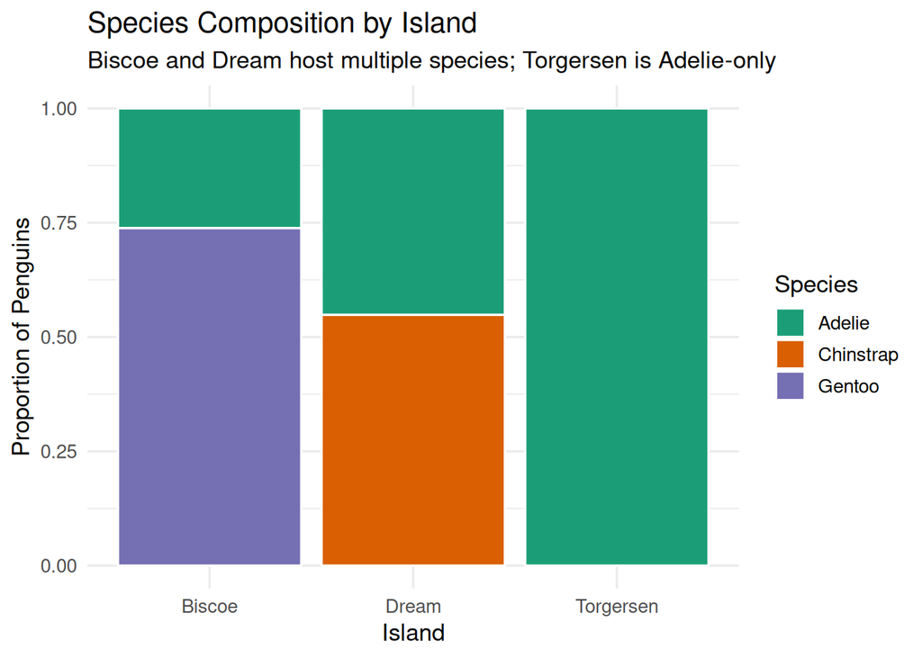

```r
# A stacked/filled bar chart showing the proportion of each species per island
penguins %>%
  filter(!is.na(species)) %>%
  ggplot(aes(x = island, fill = species)) +
  geom_bar(position = "fill", color = "white") +         # style function 1: white outlines between bars
  scale_fill_brewer(palette = "Dark2") +                 # style function 2: colorblind-friendly palette
  labs(
    title = "Species Composition by Island",
    subtitle = "Biscoe and Dream host multiple species; Torgersen is Adelie-only",
    x = "Island",
    y = "Proportion of Penguins",
    fill = "Species"
  ) +
  theme_minimal(base_size = 13)
```

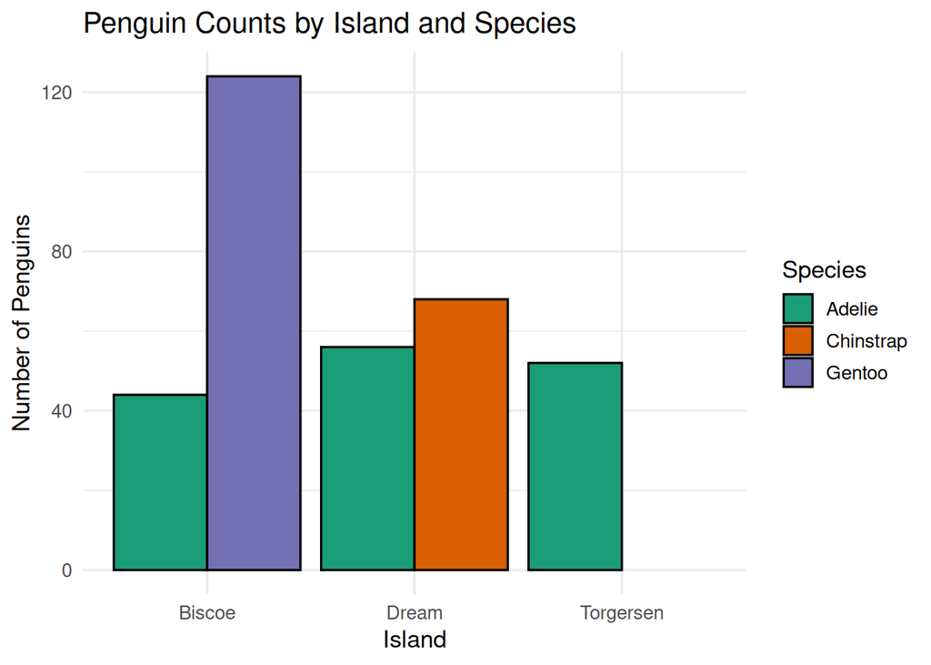

```r
# A grouped count bar chart shows raw sample sizes per island/species,
# complementing the proportion view above
penguins %>%
  filter(!is.na(species)) %>%
  ggplot(aes(x = island, fill = species)) +
  geom_bar(position = position_dodge(preserve = "single"), color = "black") + # style function 1: dodge + outline
  scale_fill_brewer(palette = "Dark2") +               # style function 2: colorblind-friendly palette
  labs(
    title = "Penguin Counts by Island and Species",
    x = "Island",
    y = "Number of Penguins",
    fill = "Species"
  ) +
  theme_minimal(base_size = 13)
```

Torgersen island is home only to Adelie penguins, Dream island hosts both Adelie and Chinstrap penguins, and Biscoe island hosts both Adelie and Gentoo penguins – so island alone doesn’t determine species, but it does rule some species in or out at each site.